# FigureYa29 map

Kevin; Ying Ge, Yijing Chen

2025-5-20

## 需求描述

## requirement description

用R画出种质资源分布图，在地图上用不同颜色展示各个group的地理分布，中国的省用饼图展示。

Draw a map of the distribution of germplasm resources in R. Show the geographic distribution of each group on the map in different colors, and the provinces of China in a pie chart.

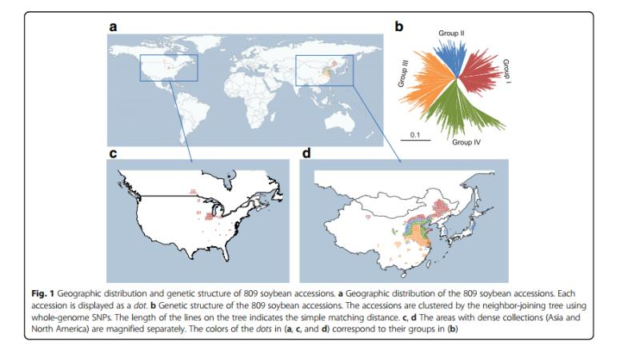

出自https://genomebiology.biomedcentral.com/articles/10.1186/s13059-017-1289-9

fromhttps://genomebiology.biomedcentral.com/articles/10.1186/s13059-017-1289-9

## 应用场景

## application scenario

在地图上展示特征的地理分布。

场景一：种质资源的地理分布

场景二：疾病在不同地区的发病情况

Show the geographic distribution of features on a map.

Scenario 1: Geographic distribution of germplasm resources

Scenario 2: Disease incidence in different regions

## 输入数据预处理

## Preprocessing of input data

如果你的数据像`easy_input.csv`那样，已经有经纬度，就可以跳过这步，直接进入“开始画图”。

输入数据来源：https://static-content.springer.com/esm/art%3A10.1186%2Fs13059-017-1289-9/MediaObjects/13059_2017_1289_MOESM1_ESM.xlsx

输入数据没有提供点的经纬度，只有省和直辖市名，我们需要根据省份的名字提取经纬度。

If your data already has latitude and longitude like `easy_input.csv`, you can skip this step and go directly to “Start drawing”.

Input data source: https://static-content.springer.com/esm/art%3A10.1186%2Fs13059-017-1289-9/MediaObjects/13059_2017_1289_MOESM1_ESM.xlsx

The input data does not provide the latitude and longitude of the points, only the name of the province and municipality, we need to extract the latitude and longitude based on the name of the province.

```r
df=read.csv("not_easy_input.csv", sep = ";", stringsAsFactors=F)
head(df)
```

```
##                  PI.CGN....Name   NBT.ID     Type          Origin Depth
## 1                    Yu Shi Dou IGDB-063 Landrace Liaoning, China  8.22
## 2 Yu Jiang Wu Yue Niu Mao Huang IGDB-064 Landrace  Jiangsu, China  9.40
## 3            You Pi Zhi Hei Dou IGDB-065 Landrace   Shanxi, China 12.60
## 4      Yi Zheng Da Li Huang Dou IGDB-066 Landrace  Jiangsu, China 12.23
## 5       Xin Xian Xiao Huang Dou IGDB-067 Landrace   Shanxi, China 12.63
## 6                   Xiao Mi Dou IGDB-068 Landrace Shandong, China  7.85
##   Coverage            Note NCGRC..ID.
## 1     0.80 Core collection
## 2     0.88 Core collection
## 3     0.90 Core collection
## 4     0.91 Core collection
## 5     0.94 Core collection
## 6     0.89 Core collection   ZDD02913
```

```r
dim(df)
```

```
## [1] 809   8
```

```r
table(df$Type)
```

```
##
## Improved cultivar          Landrace
##               388               421
```

后面将用两种颜色，分别展示两种`type`的地理分布

The geographic distribution of each of the two `type` will be shown later in two colors

### 提取有用的列

### Extract useful columns

```r
area <- df$Origin
l <- strsplit(area,", ")

# 下面三个list分别对应输入文件中的省、国家和type（顺序对应）
# The following three lists correspond to the province, country, and type in the input file (in that order)
province <- c()
country <- c()
type <- c()

j=1
for(i in 1:length(l)){
  #删掉缺失省或国家信息的行
  #delete lines with missing provincial or national information
  if(length(l[[i]]) == 2) {
    province[j] = l[[i]][1]
    country[j] = l[[i]][2]
    type[j] = df$Type[j]
    j = j+1
    }
}

#cpt为整理后的输入文件（包含国家、省、type）
#cpt is the organized input file (contains country, province, type)
cpt <- cbind(country, province, type)
cpt <- as.data.frame(cpt)
head(cpt)
```

```
##   country province     type
## 1   China Liaoning Landrace
## 2   China  Jiangsu Landrace
## 3   China   Shanxi Landrace
## 4   China  Jiangsu Landrace
## 5   China   Shanxi Landrace
## 6   China Shandong Landrace
```

```r
dim(cpt)
```

```
## [1] 777   3
```

### 提取经纬度

### Extract latitude and longitude

`province.csv`文件是世界各国省市的经纬度对照关系表，已经把省市经纬度处理成省市的中心位置。也可以用你有自己的对照表替换这个文件。

获得`province.csv`过程描述：

1. 从simplemaps.com下载国家省市城市经纬度表(包括一些无用列)；
2. 用perl提取相关5列(国家省市城市经纬度)；
3. 将每个省市的城市的经纬度做了取平均处理(保证得到省市中心位置的经纬度)；
4. 最后得到`province.csv`

The `province.csv` file is a table of latitude and longitude correspondences for provinces and cities worldwide. The latitude and longitude of the provinces and cities have been converted to their central positions. You can also replace this file with your own correspondence table.

Get `province.csv` process description:

1. download the table of latitude and longitude of national provinces and cities from simplemaps.com (including some useless columns);
2. use perl to extract the relevant 5 columns (latitude and longitude of national provinces and cities);
3. averaging the latitude and longitude of the cities in each province (to ensure that we get the latitude and longitude of the center of the provincial city);
4. Finally, we get `province.csv`.

```r
pro <- read.csv("province.csv", header=T, stringsAsFactors=F)
head(pro)
```

```
##       country   province      lng      lat
## 1 Afghanistan Badakhshan 70.57925 37.12976
## 2 Afghanistan    Badghis 63.13330 34.98300
## 3 Afghanistan    Baghlan 68.70019 36.04520
## 4 Afghanistan      Balkh 66.99988 36.72506
## 5 Afghanistan     Bamyan 67.52104 34.82106
## 6 Afghanistan      Farah 62.09682 32.39173
```

```r
# 提取输入文件中的省市的经纬度
# extract the latitude and longitude of the provinces and cities in the input file
cpll <- pro[pro$country == country[1]&pro$province == province[1],]
for(i in 2:length(province)){
  cpll = rbind(cpll, pro[pro$country == country[i]&pro$province == province[i],])
}

cpll$type<-cpt$type

#输出到文件
#output to file
write.csv(cpll, "easy_input.csv", quote = F, row.names = F)
```

## 开始画图

## Start drawing

提供三种类型的画图代码，分别画世界、美国和中国地图，挑选自己喜欢的类型画感兴趣的地区即可。

Provide three types of plotting code for drawing maps of the world, the United States, and China. just pick your favorite type to draw the area of interest.

```r
#install.packages(c("maps","mapproj","maptools","ggsn"))
library(ggplot2)
library(maps)
library(mapproj)
library(maptools) #使用的为maptools_1.1-8.tar.gz use maptools_1.1-8.tar.gz.
#输入数据必须包含这三列：类型、经度和纬度。
#the input data must contain these three columns: type, longitude and latitude.
cpll<-read.csv("easy_input.csv")
head(cpll)
```

```
##   country province      lng      lat     type
## 1   China Liaoning 122.4327 41.02662 Landrace
## 2   China  Jiangsu 119.4203 32.87194 Landrace
## 3   China   Shanxi 112.5318 37.42189 Landrace
## 4   China  Jiangsu 119.4203 32.87194 Landrace
## 5   China   Shanxi 112.5318 37.42189 Landrace
## 6   China Shandong 118.3065 36.21946 Landrace
```

```r
summary(cpll)
```

```
##    country            province              lng              lat
##  Length:777         Length:777         Min.   :-93.66   Min.   :22.56
##  Class :character   Class :character   1st Qu.:112.53   1st Qu.:34.36
##  Mode  :character   Mode  :character   Median :116.12   Median :37.42
##                                        Mean   : 98.81   Mean   :37.93
##                                        3rd Qu.:122.43   3rd Qu.:41.03
##                                        Max.   :142.16   Max.   :48.06
##      type
##  Length:777
##  Class :character
##  Mode  :character
##
##
##
```

此处的输入文件只精确到省，每个省有多行。

The input file here is only accurate to the province, with multiple lines per province.

### 各省每种type的数量作为点的size，以世界地图为例

### The number of each type in each province as the point size, in the case of a world map

```r
library(plyr)
library(dplyr)

# type的unique行计数
# unique row count for type
cpllt<-read.csv("easy_input.csv")
dim(cpllt)
```

```
## [1] 777   5
```

```r
cpllt_uni <- ddply(cpllt,.(country,province,lng,lat,type),nrow)
dim(cpllt_uni)
```

```
## [1] 94  6
```

```r
names(cpllt_uni)[6] <- "type_num"
head(cpllt_uni)
```

```
##   country province       lng      lat              type type_num
## 1  Canada  Ontario -83.33214 47.34899 Improved cultivar       10
## 2  Canada  Ontario -83.33214 47.34899          Landrace        1
## 3   China    Anhui 117.18495 32.18472 Improved cultivar       14
## 4   China    Anhui 117.18495 32.18472          Landrace       12
## 5   China  Beijing 116.12422 39.89790 Improved cultivar       45
## 6   China  Beijing 116.12422 39.89790          Landrace       27
```

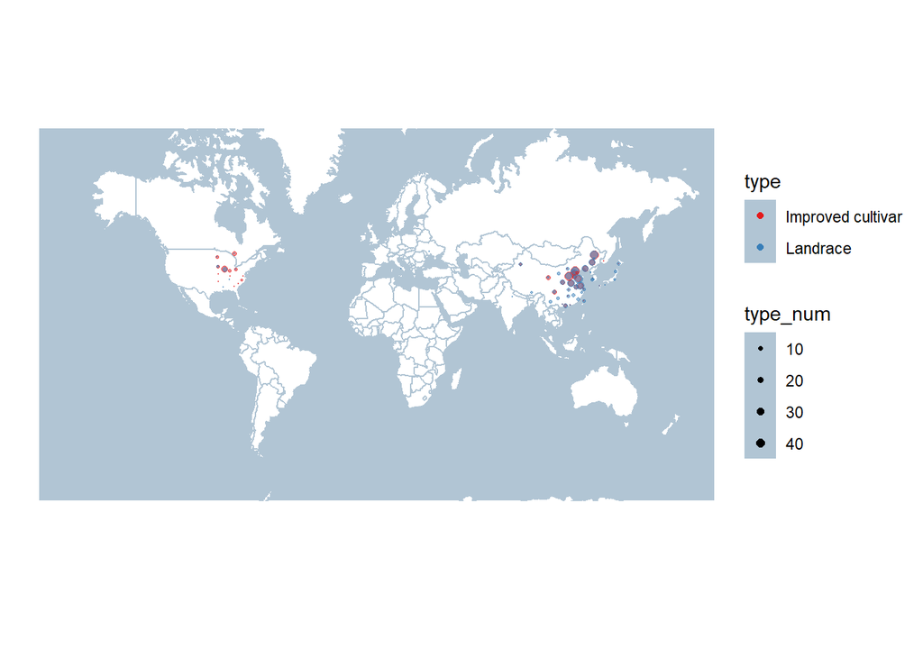

```r
world_map <- map_data("world")
pa <- ggplot() +
  geom_polygon(data=world_map,
               aes(x=long,y=lat,group=group),
               fill="white",
               colour = "#B1C5D4") + #蓝色国家边界 blue state border
  theme(panel.background = element_rect(fill = "#B1C5D4")) + #蓝色海洋 blue sea
  geom_point(data = cpllt_uni, aes(x = lng, y = lat,
                                  size = type_num, #点的大小代表type的数量 the size of the dot represents the number of type
                                  colour = type, #type用不同颜色展示 type is displayed in different colors
                                  alpha = I(0.5))) + #点的透明度 transparency of dot
  scale_size_continuous(range = c(0.1,2)) + #点的大小范围 range of dot sizes
  scale_color_brewer(palette = "Set1") +

  xlab("") + ylab("") +
  theme(panel.grid =element_blank()) + #去除网格线 remove gridlines
  theme(panel.border = element_blank()) + #去除外层边框 remove outer border
  theme(axis.line = element_blank(), axis.ticks = element_blank(), axis.text = element_blank()) + #去除x轴 remove x-axis
  coord_map(xlim=c(-180, 180), ylim=c(-60, 80))
pa
```

```r
ggsave("world_size.pdf")
```

### 分散画出省内所有的点，以美国为例

### Decentralize the drawing of all points within a province, using the United States as an example

前面从`province.csv`文件提取了省市中心位置的经纬度，我们把同一个省的点分散显示。

Having extracted the latitude and longitude of the location of the center of the province from the `province.csv` file earlier, let’s show the points of the same province in a decentralized way.

```r
#随机移动点，获得新的经纬度
#randomly move points to get a new latitude and longitude
set.seed(1)
lat_random <- sample(seq(-0.5,0.5,0.1),nrow(cpllt),replace=T)
lng_random <- sample(seq(-0.5,0.5,0.1),nrow(cpllt),replace=T)
cpllt_random <- cbind(cpllt[,1:2], lng = cpllt[,3] + lng_random,lat = cpllt[,4] + lat_random, type = cpllt$type)
head(cpllt_random)
```

```
##   country province      lng      lat     type
## 1   China Liaoning 122.2327 41.32662 Landrace
## 2   China  Jiangsu 119.2203 32.67194 Landrace
## 3   China   Shanxi 112.8318 37.52189 Landrace
## 4   China  Jiangsu 119.1203 32.37194 Landrace
## 5   China   Shanxi 113.0318 37.02189 Landrace
## 6   China Shandong 118.6065 36.31946 Landrace
```

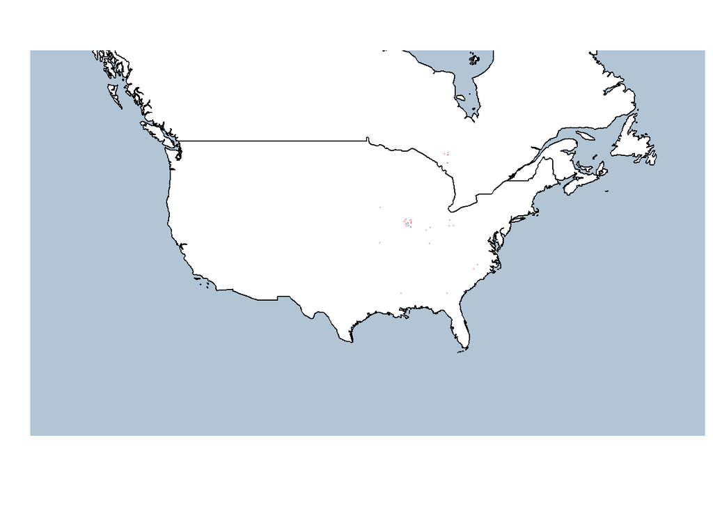

```r
#查询某单独地区的名称
#search for the name of an individual region
#sort(unique(world_map$region)) #一共有252个地区 a total of 252 districts

USA_map <- map_data("world",region = c("USA","canada"))
pc <- ggplot() +
  geom_polygon(data = USA_map,
               aes(x = long, y = lat,group = group),
               fill = "white",
               colour = "black") + #黑色国家边界 black state border
  theme(panel.background = element_rect(fill = "#B1C5D4")) +
  geom_point(data = cpllt_random[cpllt_random$country == c("United States","Canada"),], aes(x = lng, y = lat, colour = type), size = 0.1, alpha = I(0.4)) +
  scale_color_brewer(palette = "Set1") +

  xlab("") + ylab("") +
  theme(panel.grid =element_blank()) +
  theme(panel.border = element_blank()) +
  theme(axis.line = element_blank(), axis.ticks = element_blank(), axis.text = element_blank()) +
  guides(colour = FALSE) +
  coord_map(xlim=c(-140, -50), ylim=c(15, 55))
pc
```

```r
ggsave("US_points.pdf")
```

### 饼图展示各省type的占比，以中国为例

### Pie chart showing the percentage of type by province, using China as an example

先计算各省type的百分比

First calculate the percentage of each province type

```r
library(plyr)
library(dplyr)

#type的unique行计数
#unique row count for type
cpllt<-read.csv("easy_input.csv")
cpllt_uni <- ddply(cpllt,.(country,province,lng,lat,type),nrow)
names(cpllt_uni)[6] <- "type_num"
llt<-cpllt_uni[,c(-1,-2)]
head(llt)
```

```
##         lng      lat              type type_num
## 1 -83.33214 47.34899 Improved cultivar       10
## 2 -83.33214 47.34899          Landrace        1
## 3 117.18495 32.18472 Improved cultivar       14
## 4 117.18495 32.18472          Landrace       12
## 5 116.12422 39.89790 Improved cultivar       45
## 6 116.12422 39.89790          Landrace       27
```

```r
#提取不同type的个数，此处有两个type，根据实际需要增加
#extract the number of different types, here there are two types, according to the actual need to increase
llt1<-llt[llt$type=="Improved cultivar",]
colnames(llt1)[4]<-"cultivar"
llt2<-llt[llt$type=="Landrace",]
colnames(llt2)[4]<-"Landrace"

lltall<-merge(llt1, llt2, by = c("lng","lat"))
lltall<-lltall[,c(-3,-5)]

#计算该省的数量在全世界所占的百分比，用来画pie的半径
#calculate the percentage of this province's quantity in the world to be used as the radius of the pie
type_sum <- sum(cpllt_uni$type_num)
lltall$total<-lltall$`cultivar` + lltall$Landrace
lltall$radius<-log10(lltall$total / type_sum * 1000)

lltall$region<-seq(1:nrow(lltall))
head(lltall)
```

```
##         lng      lat cultivar Landrace total    radius region
## 1 -82.79722 40.53262        4        1     5 0.8085490      1
## 2 -83.33214 47.34899       10        1    11 1.1509717      2
## 3 -89.08165 40.53743       23        9    32 1.6147290      3
## 4 -93.02437 42.01447        4        2     6 0.8877302      4
## 5 -93.65777 45.81776        3        1     4 0.7116390      5
## 6 100.72759 36.95456        8        2    10 1.1095790      6
```

用到了Y叔的`scatterpie`包，https://mp.weixin.qq.com/s/Jca8BqGFCLTa0aaLrQFNHA

Used Uncle Y’s `scatterpie` package, https://mp.weixin.qq.com/s/Jca8BqGFCLTa0aaLrQFNHA

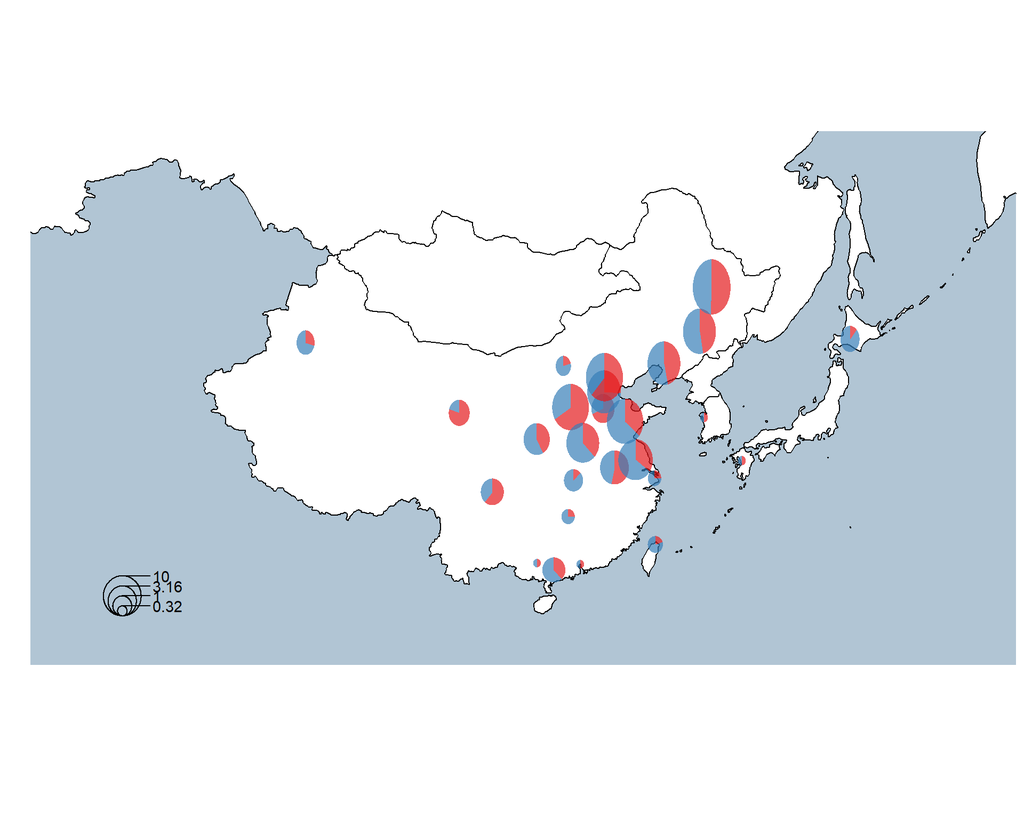

```r
#install.packages("scatterpie")
library(scatterpie)

China_map <- map_data("world",region=c("China","Taiwan","Japan","South Korea","North Korea","Mongolia","Russia"))
pd <- ggplot() +
  geom_polygon(data=China_map,
               aes(x=long,y=lat,group=group),
               fill="white",
               colour="black") +
  theme(panel.background = element_rect(fill = "#B1C5D4")) +

  geom_scatterpie(aes(x=lng, y=lat, group=region, r=radius),
                  data=lltall, cols=c("cultivar","Landrace"),
                  color=NA, #不画pie的边界 boundary without drawing a pie
                  alpha=.7) + #透明度 transparency
  #pie半径的图例，展示该省所有数据占全世界的百分比
  #legend for pie radius, showing all data for the province as a percentage of the whole world
  geom_scatterpie_legend(lltall$radius, x=65, y=20,
                         n = 3, #图例里画几个圈 how many circles are drawn in the legend
                         labeller = function(x) round(0.1*10^x,2)) +
  scale_fill_brewer(palette = "Set1") + #设置pie里的颜色 set the color in the pie
  guides(fill = FALSE) + #不显示图例 legend not displayed

  xlab("") + ylab("") +
  theme(panel.grid =element_blank()) +
  theme(panel.border = element_blank()) +
  theme(axis.line = element_blank(), axis.ticks = element_blank(), axis.text = element_blank()) +
  coord_map(xlim=c(60, 155), ylim=c(15, 55))
pd
```

```r
ggsave("China_pie.pdf",width = 10,height = 8)
```

### 组图

### Combined pictures

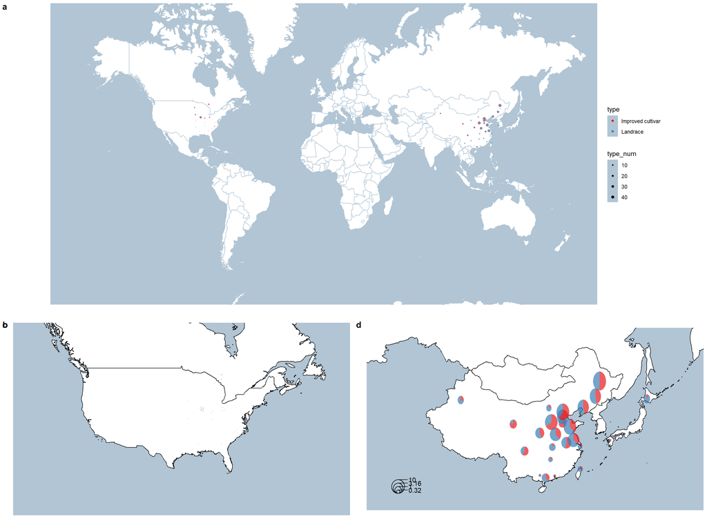

```r
library(cowplot)
plot_grid(pa, ncol = 1, labels = c("a", "b"),
  plot_grid(pc, pd, ncol = 2, labels = c("c","d")),
  rel_heights = c(1.5, 1))
```

```r
ggsave("map.pdf",width = 16,height = 12)
```